# 전이학습

[전이 학습 및 미세 조정 튜토리얼](https://www.tensorflow.org/tutorials/images/transfer_learning?hl=ko)

```python
import matplotlib.pyplot as plt
import numpy as np
import os
import tensorflow as tf
```

## 데이터 전처리

```python
# 데이터 다운로드
_URL = 'https://storage.googleapis.com/mledu-datasets/cats_and_dogs_filtered.zip'
path_to_zip = tf.keras.utils.get_file('cats_and_dogs.zip', origin=_URL, extract=True)
PATH = os.path.join(os.path.dirname(path_to_zip), 'cats_and_dogs_filtered')

train_dir = os.path.join(PATH, 'train') # 훈련 데이터 디렉토리
validation_dir = os.path.join(PATH, 'validation') # 검증 데이터 디렉토리

BATCH_SIZE = 32
IMG_SIZE = (160, 160)

train_dataset = tf.keras.utils.image_dataset_from_directory(train_dir,
                                                            shuffle=True,
                                                            batch_size=BATCH_SIZE,
                                                            image_size=IMG_SIZE)
```

```
Downloading data from https://storage.googleapis.com/mledu-datasets/cats_and_dogs_filtered.zip
Found 2000 files belonging to 2 classes.
```

```python
validation_dataset = tf.keras.utils.image_dataset_from_directory(validation_dir,
                                                                 shuffle=True,
                                                                 batch_size=BATCH_SIZE,
                                                                 image_size=IMG_SIZE)
```

```
Found 1000 files belonging to 2 classes.
```

### `image_dataset_from_directory()`

디렉토리에서 이미지 데이터셋을 만들기 위해 사용되는 함수로 주어진 디렉토리에서 이미지 파일을 로드하고, 자동으로 레이블을 할당하여 tf.data.Dataset객체를 반환합니다.

**options**

- directory: 이미지 파일이 있는 디렉토리의 경로를 지정합니다.
- labels: 레이블을 지정하는 방법을 나타내는 옵션입니다. 기본값은 "infer"로, 디렉토리의 하위 디렉토리 이름을 사용하여 자동으로 레이블을 추론합니다. 레이블을 수동으로 제공하려면 딕셔너리를 전달할 수도 있습니다.
- label_mode: 레이블 모드를 지정하는 옵션입니다. "int"는 정수 레이블, "categorical"은 원-핫 인코딩된 범주형 레이블, "binary"는 이진 레이블, "sparse"는 정수 레이블을 사용하는 경우를 나타냅니다. 기본값은 "categorical"입니다.
- class_names: 클래스 이름을 지정하는 옵션입니다. 레이블이 문자열로 주어진 경우 사용할 수 있습니다.
- color_mode: 이미지의 색상 모드를 지정하는 옵션입니다. "grayscale"는 흑백 이미지, "rgb"는 컬러 이미지, "rgba"는 투명도를 포함한 컬러 이미지를 나타냅니다. 기본값은 "rgb"입니다.
- batch_size: 생성할 배치의 크기를 지정하는 옵션입니다. 기본값은 32입니다.
- image_size: 이미지의 크기를 지정하는 옵션입니다. (높이, 너비)의 튜플로 지정합니다.
- validation_split: 유효성 검사에 사용할 데이터의 비율을 나타내는 옵션입니다. 0과 1 사이의 값으로 지정하며, 예를 들어 0.2는 전체 데이터 중 20%를 유효성 검사에 사용합니다.

```
['cats', 'dogs']
```

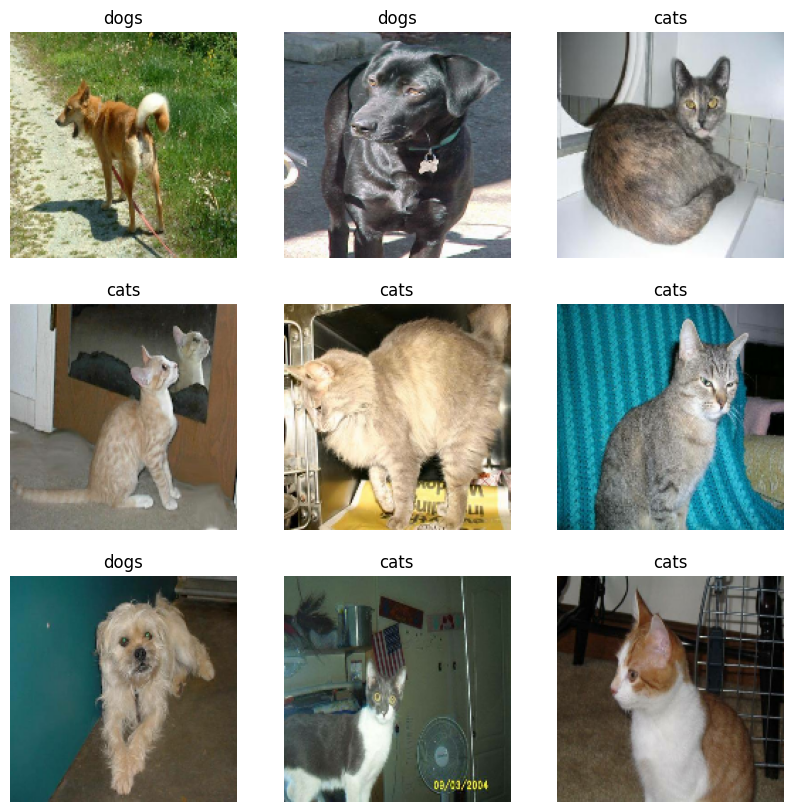

```python
class_names = train_dataset.class_names # 레이블
print(class_names)

plt.figure(figsize=(10, 10))
for images, labels in train_dataset.take(1): # 배치사이즈 32로 이루어진 작업 중 9개의 이미지 확인
  for i in range(9):
    ax = plt.subplot(3, 3, i + 1)
    plt.imshow(images[i].numpy().astype("uint8"))
    plt.title(class_names[labels[i]])
    plt.axis("off")
```

```python
# 검증데이터 세트에서 테스트 데이터 세트 추출하기
val_batches = tf.data.experimental.cardinality(validation_dataset)
test_dataset = validation_dataset.take(val_batches // 5) # 검증데이터셋에서 20%를 추출하여 테스트 데이터 셋로 할당
validation_dataset = validation_dataset.skip(val_batches // 5) # skip()은 pop()과 유사하게 이해하면 됌
```

- `tf.data.experimental.cardinality()` : 주어진 데이터셋의 크기를 추정하여 반환합니다. 이 추정치는 실제 크기가 아닐 수 있으며, 데이터셋의 크기를 정확하게 알 수 없는 경우에 유용합니다.

```python
print('Number of validation batches: %d' % tf.data.experimental.cardinality(validation_dataset))
print('Number of test batches: %d' % tf.data.experimental.cardinality(test_dataset))
```

```
Number of validation batches: 26
Number of test batches: 6
```

```python
# 데이터세트 최적화
AUTOTUNE = tf.data.AUTOTUNE

train_dataset = train_dataset.prefetch(buffer_size=AUTOTUNE)
validation_dataset = validation_dataset.prefetch(buffer_size=AUTOTUNE)
test_dataset = test_dataset.prefetch(buffer_size=AUTOTUNE)
```

```python
# 이미지 데이터 증강 | model.fit을 호출 할 때 훈련 중에만 아래 레이어가 활성화 됌
data_augmentation = tf.keras.Sequential([
  tf.keras.layers.RandomFlip('horizontal'), # 무작위로 이미지를 수평으로 뒤집는 데이터 증강
  tf.keras.layers.RandomRotation(0.2), # -0.2 ~ 0.2 사이의 각도 범위 내에서 랜덤하게 이미지를 회전
])
```

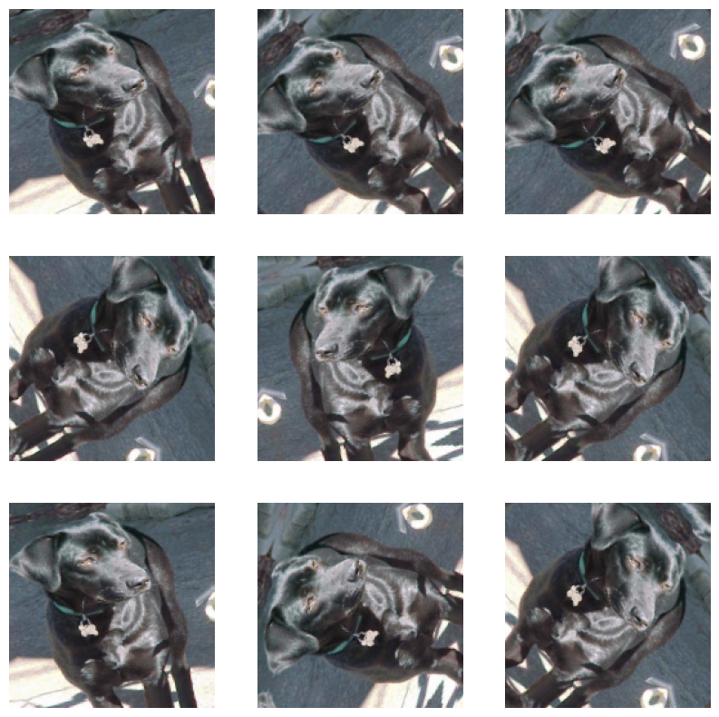

```python
# 데이터 증강 확인
for image, _ in train_dataset.take(1):
  plt.figure(figsize=(10, 10))
  first_image = image[0]
  for i in range(9):
    ax = plt.subplot(3, 3, i + 1)
    augmented_image = data_augmentation(tf.expand_dims(first_image, 0))
    plt.imshow(augmented_image[0] / 255)
    plt.axis('off')
```

```python
# 픽셀 값 재조정 | 이 모델은 [-1,1]의 픽셀 값을 예상함
preprocess_input = tf.keras.applications.mobilenet_v2.preprocess_input
```

## 사전 훈련된 CNN으로부터 기본 모델 생성하기

google에서 개발한 MobileNet V2 모델은 1000개의 클래스(레이블)로 구성된 ImageNet 데이터셋을 사용해 사전 훈련된 모델입니다.

```python
# 인스턴스 생성
IMG_SHAPE = IMG_SIZE + (3,)
base_model = tf.keras.applications.MobileNetV2(input_shape=IMG_SHAPE,
                                               include_top=False,
                                               weights='imagenet')
```

```
Downloading data from https://storage.googleapis.com/tensorflow/keras-applications/mobilenet_v2/mobilenet_v2_weights_tf_dim_ordering_tf_kernels_1.0_160_no_top.h5
```

### `MobileNetV2()`의 옵션

- input_shape: 모델의 입력 이미지의 형태를 지정하는 옵션입니다. (height, width, channels) 형태의 튜플로 지정합니다. 예를 들어, (224, 224, 3)은 224x224 크기의 RGB 이미지를 나타냅니다.
- include_top: 모델의 최상위 레이어를 포함할지 여부를 나타내는 옵션입니다. 기본값은 False로, 최상위 레이어를 포함하지 않고 모델의 특성 추출기 부분만 생성합니다. True로 설정하면, MobileNet V2의 완전 연결 계층으로 이루어진 분류기도 함께 생성됩니다.
- weights: 사전 학습된 가중치를 지정하는 옵션입니다. 기본값은 None으로, 사전 학습된 가중치를 사용하지 않고 모델을 무작위로 초기화합니다. 'imagenet'으로 설정하면 ImageNet 데이터셋에서 사전 학습된 가중치를 로드합니다.
- pooling: 특성 추출 후에 적용할 풀링 작업을 지정하는 옵션입니다. 기본값은 None으로, 특성 맵을 평탄화하지 않고 반환합니다. 'avg' 또는 'max'로 설정하면, 각각 평균 풀링 또는 최대 풀링 작업을 적용하여 특성 맵을 하나의 벡터로 변환합니다.
- alpha: 모델의 네트워크 너비 조절을 위한 스케일 파라미터로, 실수 값으로 지정합니다. 기본값은 1.0으로, 원래 MobileNet V2 아키텍처의 너비를 나타냅니다. 값이 1보다 작으면 모델의 너비가 축소되고, 값이 1보다 크면 너비가 확대됩니다.

```python
# 기존 (160,160,3)의 이미지를 (5,5,1280)개의 특징 블록으로 변환
image_batch, label_batch = next(iter(train_dataset)) # 훈련 데이터셋에서 하나의 배치를 추출
feature_batch = base_model(image_batch) # MobileNetV2모델을 이용하여 특징 추출
print(feature_batch.shape)
```

```
(32, 5, 5, 1280)
```

## 특징 추출

```python
# 컨볼루션 베이스 모델 고정하기 | 주어진 레이어의 weight가 업데이트 되는 것을 방지
base_model.trainable = False
```

### `kt.keras.layers.BatchNormalization()`

많은 딥러닝 모델에서 사용되는 정규화 기법입니다.  
`layer.trainable = False`를 설정하면 `BatchNormalization` 레이어가 **추론 모드**에서 실행되고 평균 및 분산 통계를 업데이트 하지 않습니다.

미세 조정을 위해 모델을 동결 해제하면 기본 모델을 호출할 떄 `training = False`를 전달하여 `BatchNormalizaion`레이어를 **추론 모드**로 유지해야 합니다.  
그렇지 않으면 훈련 불가능한 weight에 적용된 업데이트로 인해 모델이 학습한 내용이 파괴됩니다.

```python
base_model.summary()
```

[output not shown]

[output cut: 343 more lines]

[output not shown]

```python
# 분류 층을 멘 위에 추가하기
global_average_layer = tf.keras.layers.GlobalAveragePooling2D() # 이미지당 고정된 길이의 특성 백터로 변환
feature_batch_average = global_average_layer(feature_batch) # 5x5 공간 위치에 대한 평균
print(feature_batch_average.shape)
```

```
(32, 1280)
```

### `tf.keras.layers.GlobalAveragePooling2D()`

2D 특성 맵을 글로벌 평균 풀링하는 역할을 하는 Keras 층(layer)입니다. 이 층은 주어진 입력 특성 맵의 공간 차원을 제거하고 각 채널의 평균값을 계산합니다. 이를 통해 공간 정보를 요약하고, 고정된 길이의 특성 벡터를 얻을 수 있습니다.

2D 컨볼루션 신경망에서 일반적으로 사용되는 구조는 컨볼루션 레이어를 여러 개 쌓은 뒤, 최종적으로 글로벌 평균 풀링 레이어를 추가하는 것입니다. 이는 모델의 파라미터 수를 줄이고, 과적합을 방지하며, 모델의 일반화 성능을 향상시키는 데 도움을 줄 수 있습니다.

tf.keras.layers.GlobalAveragePooling2D는 입력으로 주어진 2D 특성 맵에 대해 글로벌 평균 풀링을 수행합니다. 이 층은 입력으로 받은 특성 맵의 각 채널별로 평균을 계산하고, 채널 개수에 상관없이 동일한 크기의 출력을 생성합니다. 따라서 출력은 공간 차원이 없고, 채널 차원만 존재하는 1D 특성 벡터가 됩니다.

글로벌 평균 풀링은 주로 이미지 분류 작업에서 활용되며, 컨볼루션 신경망의 특성 추출기로 사용된 후에 분류기로 전달되는 경우가 많습니다. 특성 맵의 공간 정보를 요약하여 컴퓨팅 비용을 줄이고, 입력 이미지의 크기에 상관없이 일관된 크기의 특성 벡터를 얻을 수 있습니다.

```python
prediction_layer = tf.keras.layers.Dense(1) # 이미지당 단일 예측(개냐 고양이냐) | 원시 예측으로 활성화 함수가 필요하지 않음
prediction_batch = prediction_layer(feature_batch_average)
print(prediction_batch.shape) # 양수는 클래스 1 음수는 클래스 0을 예측
```

```
(32, 1)
```

```python
# 함수형 모델 제작
inputs = tf.keras.Input(shape=(160, 160, 3))
x = data_augmentation(inputs) # 데이터 증강
x = preprocess_input(x) # 전처리
x = base_model(x, training=False) # MobileNetV2모델 | BatchNormalzation 레이어가 포함되어 있으므로 traiing=False
x = global_average_layer(x)
x = tf.keras.layers.Dropout(0.2)(x)
outputs = prediction_layer(x)
model = tf.keras.Model(inputs, outputs)
```

```python
# 모델 컴파일 | 이중분류
base_learning_rate = 0.0001 # 가중치 업데이트할 때 사용되는 학습률 | default = 0.001
model.compile(optimizer=tf.keras.optimizers.Adam(learning_rate=base_learning_rate),
              loss=tf.keras.losses.BinaryCrossentropy(from_logits=True),
              metrics=['accuracy'])
```

```python
model.summary()
```

[output not shown]

## 모델 훈련

```python
initial_epochs = 3

loss0, accuracy0 = model.evaluate(validation_dataset)
```

```python
print("initial loss: {:.2f}".format(loss0))
print("initial accuracy: {:.2f}".format(accuracy0))
```

```
initial loss: 0.14
initial accuracy: 0.96
```

```python
history = model.fit(train_dataset,
                    epochs=initial_epochs,
                    validation_data=validation_dataset)
```

## 학습 곡선

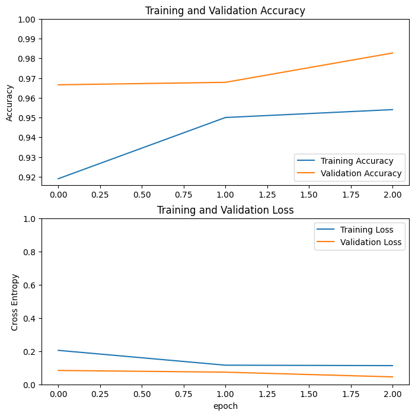

```python
acc = history.history['accuracy']
val_acc = history.history['val_accuracy']

loss = history.history['loss']
val_loss = history.history['val_loss']

plt.figure(figsize=(8, 8))
plt.subplot(2, 1, 1)
plt.plot(acc, label='Training Accuracy')
plt.plot(val_acc, label='Validation Accuracy')
plt.legend(loc='lower right')
plt.ylabel('Accuracy')
plt.ylim([min(plt.ylim()),1])
plt.title('Training and Validation Accuracy')

plt.subplot(2, 1, 2)
plt.plot(loss, label='Training Loss')
plt.plot(val_loss, label='Validation Loss')
plt.legend(loc='upper right')
plt.ylabel('Cross Entropy')
plt.ylim([0,1.0])
plt.title('Training and Validation Loss')
plt.xlabel('epoch')
plt.show()
```

## 미세 조정(튜닝)

성능을 더욱 향상시키는 한 가지 방법은 사전 훈련된 모델의 최상위 레이어 가중치를 튜닝하는 것입니다. 훈련을 통해 weight는 일반적인 특징 맵에서 개별 데이터셋과 관련된 특징으로 조정됩니다.

> 사전 훈련된 모델을 weight 업데이트 불가능으로 설정하여 최상위 분류기를 훈련한 후에만 시도해야 합니다.

```python
# 최상위 레이어 고정 해제하기 | 맨 아래층을 훈련 할 수 없도록 설정
base_model.trainable = True
```

```python
print("Number of layers in the base model: ", len(base_model.layers))

# Fine-tune from this layer onwards
fine_tune_at = 100

# Freeze all the layers before the `fine_tune_at` layer
for layer in base_model.layers[:fine_tune_at]:
  layer.trainable = False
```

```
Number of layers in the base model:  154
```

```python
# 모델 컴파일
model.compile(loss=tf.keras.losses.BinaryCrossentropy(from_logits=True),
              optimizer = tf.keras.optimizers.RMSprop(learning_rate=base_learning_rate/10), # 훨씬 거대한 모델을 사용하기 때문에 낮은 학습률을 사용해야 과대적합을 방지할 수 있음
              metrics=['accuracy'])
```

```python
model.summary()
```

```
Model: "model"
_________________________________________________________________
 Layer (type)                Output Shape              Param #
=================================================================
 input_2 (InputLayer)        [(None, 160, 160, 3)]     0

 sequential (Sequential)     (None, 160, 160, 3)       0

 tf.math.truediv (TFOpLambda  (None, 160, 160, 3)      0
 )

 tf.math.subtract (TFOpLambd  (None, 160, 160, 3)      0
 a)

 mobilenetv2_1.00_160 (Funct  (None, 5, 5, 1280)       2257984
 ional)

 global_average_pooling2d (G  (None, 1280)             0
 lobalAveragePooling2D)

 dropout (Dropout)           (None, 1280)              0

 dense (Dense)               (None, 1)                 1281

=================================================================
Total params: 2,259,265
Trainable params: 1,862,721
Non-trainable params: 396,544
_________________________________________________________________
```

```python
# 모델 훈련
fine_tune_epochs = 2
total_epochs =  initial_epochs + fine_tune_epochs

history_fine = model.fit(train_dataset,
                         epochs=total_epochs,
                         initial_epoch=history.epoch[-1],
                         validation_data=validation_dataset)
```

```python
acc += history_fine.history['accuracy']
val_acc += history_fine.history['val_accuracy']

loss += history_fine.history['loss']
val_loss += history_fine.history['val_loss']
```

## 평가 및 예측

```python
loss, accuracy = model.evaluate(test_dataset)
print('Test accuracy :', accuracy)
```

```
Test accuracy : 0.984375
```

```
Predictions:
 [1 1 0 0 1 0 1 1 0 1 0 1 0 0 1 1 0 0 0 1 1 1 0 1 1 1 1 0 1 0 0 1]
Labels:
 [1 1 0 0 1 0 1 1 0 1 0 1 0 0 1 1 0 0 0 1 1 1 0 1 1 1 1 0 1 0 0 1]
```

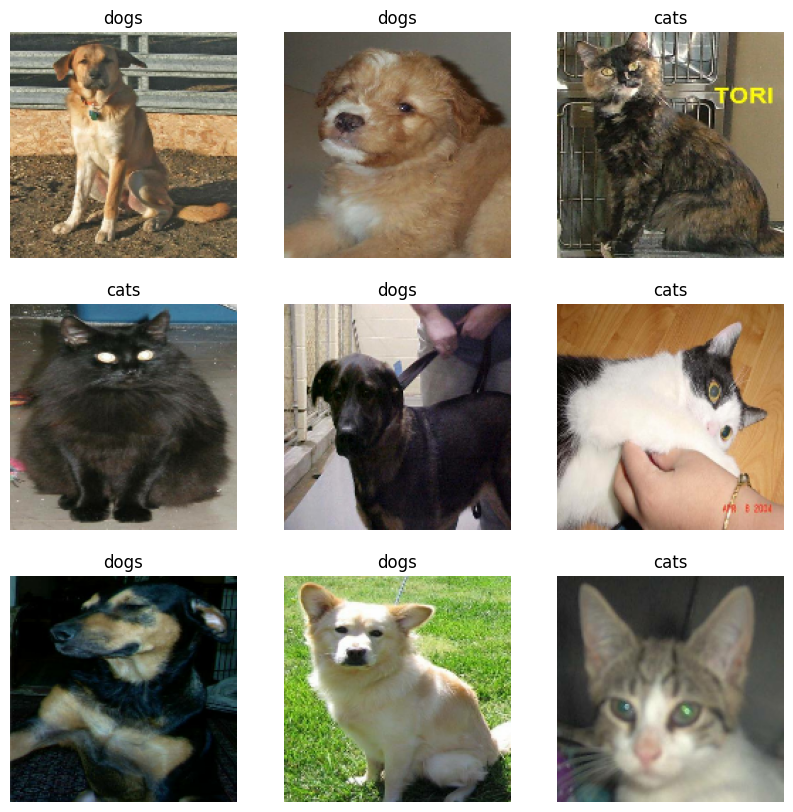

```python
# Retrieve a batch of images from the test set
image_batch, label_batch = test_dataset.as_numpy_iterator().next()
predictions = model.predict_on_batch(image_batch).flatten()

# Apply a sigmoid since our model returns logits
predictions = tf.nn.sigmoid(predictions)
predictions = tf.where(predictions < 0.5, 0, 1) # 임계값

print('Predictions:\n', predictions.numpy())
print('Labels:\n', label_batch)

plt.figure(figsize=(10, 10))
for i in range(9):
  ax = plt.subplot(3, 3, i + 1)
  plt.imshow(image_batch[i].astype("uint8"))
  plt.title(class_names[predictions[i]])
  plt.axis("off")
```

## 오차행렬

```python
from sklearn.metrics import confusion_matrix
```

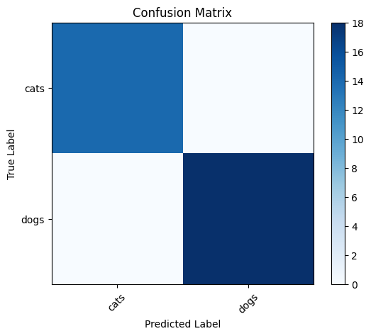

```
True Positive (TP): 18
False Positive (FP): 0
True Negative (TN): 14
False Negative (FN): 0
```

```python
# 오차 행렬 생성
cm = confusion_matrix(predictions, label_batch)

# 오차 행렬 시각화
plt.imshow(cm, interpolation='nearest', cmap=plt.cm.Blues)
plt.title('Confusion Matrix')
plt.colorbar()
tick_marks = np.arange(len(class_names))
plt.xticks(tick_marks, class_names, rotation=45)
plt.yticks(tick_marks, class_names)
plt.xlabel('Predicted Label')
plt.ylabel('True Label')
plt.show()

# TP, FP, TN, FN 계산
tp = cm[1, 1]
fp = cm[0, 1]
tn = cm[0, 0]
fn = cm[1, 0]

# 결과 출력
print("True Positive (TP):", tp)
print("False Positive (FP):", fp)
print("True Negative (TN):", tn)
print("False Negative (FN):", fn)
```

## 분류리포트

```python
from sklearn.metrics import classification_report
```

```python
# 분류 리포트 작성
report = classification_report(predictions, label_batch)

# 결과 출력
print(report)
```

```
              precision    recall  f1-score   support

           0       1.00      1.00      1.00        14
           1       1.00      1.00      1.00        18

    accuracy                           1.00        32
   macro avg       1.00      1.00      1.00        32
weighted avg       1.00      1.00      1.00        32
```

## ROC 커브

```python
from sklearn.metrics import roc_curve, auc
```

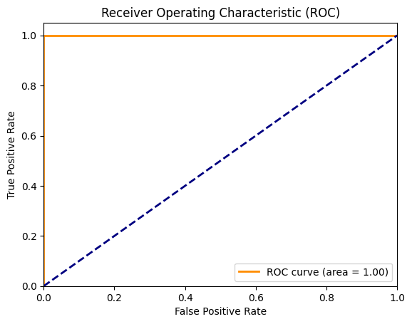

```python
# ROC 커브 계산
fpr, tpr, thresholds = roc_curve(label_batch, predictions)
roc_auc = auc(fpr, tpr)

# ROC 커브 그리기
plt.figure()
plt.plot(fpr, tpr, color='darkorange', lw=2, label='ROC curve (area = %0.2f)' % roc_auc)
plt.plot([0, 1], [0, 1], color='navy', lw=2, linestyle='--')
plt.xlim([0.0, 1.0])
plt.ylim([0.0, 1.05])
plt.xlabel('False Positive Rate')
plt.ylabel('True Positive Rate')
plt.title('Receiver Operating Characteristic (ROC)')
plt.legend(loc="lower right")
plt.show()
```

## 파일 분류

```python
import zipfile
from tensorflow.keras.preprocessing import image
import shutil
from tensorflow.keras.applications.mobilenet_v2 import preprocess_input, decode_predictions
```

```python
# 디렉토리 확인
notebook_dir = os.path.abspath(os.path.dirname('1.jpg'))
print(notebook_dir)
```

```
/content
```

```python
# 압축 파일 압축 해제
zip_file_name = 'dogandcat.zip'
with zipfile.ZipFile(zip_file_name, 'r') as zip_ref:
    zip_ref.extractall()
```

```python
def classify_image(image_path):
    img = image.load_img(image_path, target_size=IMG_SIZE)
    img = image.img_to_array(img)
    img = np.expand_dims(img, axis=0)
    img = preprocess_input(img)
    predictions = model.predict(img)
    if predictions > 0.5:
      return 'dog'
    else:
      return 'cat'

def classify_and_move_images(image_folder, output_folder):
    # output_folder 내에 dog와 cat 폴더를 생성
    os.makedirs(os.path.join(output_folder, 'dog'), exist_ok=True)
    os.makedirs(os.path.join(output_folder, 'cat'), exist_ok=True)

    # 이미지 파일들 가져오기
    image_files = os.listdir(image_folder)

    for filename in image_files:
      if os.path.splitext(filename)[1] == '.jpg':
        image_path = os.path.join(image_folder, filename)

        # 이미지 분류
        result = classify_image(image_path)

        # dog 또는 cat 폴더로 이미지 파일 이동
        if 'dog' in result:
            shutil.move(image_path, os.path.join(output_folder, 'dog', filename))
        elif 'cat' in result:
            shutil.move(image_path, os.path.join(output_folder, 'cat', filename))
```

```python
img = image.load_img('/content/dog/1.jpg', target_size=IMG_SIZE)
img = image.img_to_array(img)
img = np.expand_dims(img, axis=0)
img = preprocess_input(img)
predictions = model.predict(img)
if predictions > 0.5:
  print('dog')
else:
  print('cat')
```

```
cat
```

```python
image_dir = notebook_dir
output_dir = notebook_dir
classify_and_move_images(image_dir, output_dir)
```